# Explore the Community through Research

Divergent thinking through exploratory experiments with your people

## 1 Unearthing Unmet Needs

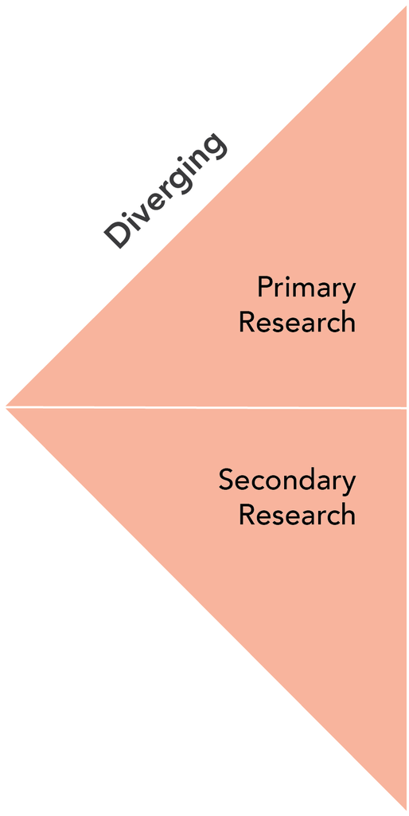

After choosing and confirming access to a community of people, the journey of entrepreneurial innovation continues with an in-depth exploration of their lives. This chapter delves into generative, exploratory experiments—our journey into divergent thinking—aimed at amassing a “mountain of data” about the selected community. At this stage, the emphasis is on extensive data collection, through both *primary* and *secondary research*, laying the groundwork for later interpretation and hypothesis formation. This process will reveal valuable insights, guiding us toward identifying unmet needs worthy of innovative solutions.

#### Learning from Failure: Gillette’s Revised Approach in India

Gillette’s revised strategy in India is a prime example of the effectiveness of starting with a thorough understanding of customer needs. Faced with the challenge that 500 million Indian men still relied on traditional safety razors, Gillette adopted a more customer-centric approach that ultimately led to a product embraced by the market.

1. **In-Depth Primary Research**: A Gillette team comprising 20 executives, developers, and engineers was dispatched to India. Over three weeks, they dedicated more than 3000 hours to engage with over 1000 potential customers.
2. **Ethnographic Insights**: he team immersed themselves in the daily routines of these men, observing shaving practices in their homes and conducting interviews about their experiences, aspirations, and the role of shaving in their lives.
3. **Informed Product Development**: With their mountain of data, Gillette innovators gleaned key insights that informed the development of a new razor. This product, tailored to the unique needs of the Indian market, underwent successful testing with customers, confirming its viability.

This chapter of Gillette’s story underscores the importance of an immersive, data-first approach. By focusing on understanding and addressing the real, unmet needs of customers, Gillette significantly reduced the risk of failure and achieved a successful innovation outcome.

## 2 Finding and Engaging Your People

In the quest for innovation, the initial step is identifying and engaging with your target community. This process is crucial, as engaging the wrong individuals can introduce bias into your research, leading to inaccurate conclusions. The keys to authentic data are:

### 2.1 Avoiding Sampling Errors

Beware of sampling errors where you inadvertently study individuals outside your intended group. For instance, if your focus is on stay-at-home fathers, finding them exclusively on general social media platforms may also lead you to men outside this category, diluting your data’s relevance.

#### The Pitfall of Convenience Sampling

Convenience sampling—relying on easily accessible but non-representative data sources—can significantly skew your results. Studying fellow students when your target audience is broader, or relying on feedback from family and friends, often leads to biased and unrepresentative data. Their desire to support you might overshadow their objectivity.

### 2.2 Strategies for Engaging Your Target Community

1. **Go to Where They Are**: Physically seek out places where your target community is likely to congregate. For example, if studying bodybuilders, consider gyms or nutritional supplement stores. Always approach with respect and mindfulness of the setting.
2. **Leveraging Social Media Effectively**:
   - Avoid using your personal social media circles for feedback, as this often constitutes convenience sampling.
   - Utilize social media groups formed around common interests relevant to your target community. Look for large, active groups.
   - Engage these groups with thought-provoking questions, polls, or surveys. Aim to transition from online interactions to more personal conversations. Provide an option for respondents to share contact details for follow-up discussions.

#### Transitioning Beyond Convenience Sampling

While some initial convenience sampling may be inevitable as you learn to identify and locate your target community, strive to move beyond it. Your data’s reliability increases significantly when it comes from well-identified, correctly located sources.

### 2.3 Addressing Access Challenges

If recognizing and accessing your target community proves challenging, it might indicate a deeper issue of accessibility. In such cases, reconsider your choice of target community to ensure feasibility and reliability in your research.

## 3 Primary Research

Primary research is pivotal in your innovation journey, as it involves direct engagement with your target community to gather original, firsthand data. This method is invaluable for generating deep insights about your people’s unmet needs, thanks to its focus on personal interaction. It is the direct study of subjects through firsthand investigation and involves collecting original data about your target community. It offers a depth of understanding that secondary, archival sources cannot match.

Primary research has significant strengths:

1. **Emotional Insights**: By interacting directly with individuals, you can observe non-verbal cues like facial expressions and body language. These subtle signals often reveal underlying emotions and reactions that are not captured in secondary data.
2. **Customized Inquiry**: Personal contact allows you to tailor your line of questioning on the fly. This flexibility means you can delve deeper into aspects of an individual’s life, especially when you uncover potential unmet needs.
3. **Nuanced Information**: Primary research provides a level of detail and nuance that is essential for truly understanding the unmet needs of your community.

However, primary research is resource-intensive, imposing significant costs:

1. **Time-Consuming**: Engaging with people one-on-one through interviews, role-playing, observation, and shadowing takes significant time.
2. **Potential Financial Costs**: In some cases, primary research may also incur financial expenses.

In contrast, secondary research, while faster and often less expensive, lacks the richness of information that primary research provides. Despite its costs, the depth and quality of data obtained from primary research are unmatched and crucial for insightful innovation.

### 3.1 Conversation and Story-Telling: Engaging with Depth

Embarking on primary research through conversation and storytelling is a critical step in understanding the lived experiences of your target community. Directly asking people to define their needs often falls short, as many struggle to articulate them. However, most are more than willing to share stories about their lives, which can inadvertently reveal their struggles and aspirations. In short, we are not good at talking about our needs but we are very good at complaining. We will leverage that through conversations that we steer toward emotion and struggles.

#### The Power of Contextual Conversations

Conducting interviews in the environment where the activities occur adds richness to the data. It not only aids memory recall but also allows participants to demonstrate their experiences, offering you deeper insight.

#### The Art of Ethnographic Interviews

Ethnographic interviews require more than just casual conversation. They are a structured method to uncover hidden needs and emotions. Here’s how to approach them effectively:[^1]

1. **Prepare an Interview Protocol**: Know whom you’ll visit, what you’ll ask, and how you’ll record responses.
2. **Gather Interview Resources**: Assemble notebooks, sketchbooks, and recording devices.
3. **Craft a Concise Introduction**: Start with a clear introduction about your project’s purpose and exchange names to establish rapport.
4. **Foster Story-Telling**: Encourage participants to share detailed experiences. Questions like “Tell me about the last time you…” or “What was memorable about that experience?” are more revealing than generic inquiries.
5. **Seek Emotional Triggers**: Emotions often indicate underlying unmet needs. Use follow-up questions to delve deeper when you sense emotions.
6. **Request Referrals**: At the end of the conversation, ask if they know others who might provide additional insights.
7. **Document Thoroughly**: Assign team members to record the conversations accurately.
8. **Team Debriefing**: After interviews, regroup to discuss findings, assess knowledge gaps, and plan for filling them.

#### Tips for Effective Conversational Engagement

To transform polite exchanges into insightful dialogues, follow these guidelines:

- Encourage storytelling with open-ended questions.
- Probe into reasons behind actions or statements.
- Focus on specific experiences rather than generalizations.
- Observe and inquire about inconsistencies in actions and words.
- Practice active listening.
- Embrace silence, allowing respondents time to reflect.
- Avoid leading questions.
- Conduct interviews in person and individually for authenticity.

Well-conducted ethnographic interviews can unlock profound insights into people’s lives, leading to valuable hypotheses about their needs.

### 3.2 Observation: Gaining Insights through Watchfulness

Observation is a crucial technique in ethnographic research. It involves watching people in their natural environment to understand their interactions with the world around them. This method goes beyond their actions to uncover underlying needs and emotions.

#### The Art of Observational Study

When observing, focus on:

- **Interactions**: How do people interact with their environment, others, tools, devices, and rules?
- **Behavior and Emotion**: Pay special attention to facial expressions and body language. Signs of frustration, confusion, or uncertainty can be indicators of unmet needs.
- **The Missing Elements**: Good innovators notice not only what is present but also what is absent. Who are the non-users or non-participants in a scenario, and why are they missing?

#### Structured Observation Approach

To structure your observational studies, consider the following questions :

1. **What are They Doing?**: Note both the obvious and the surprising. Stick to objective facts.
2. **How are They Doing It?**: Assess the effort involved, emotional responses, and the impact of the activity on the user.
3. **Why This Way?**: Make informed guesses about motivations and emotions. This helps uncover assumptions and unexpected realizations.

#### Example: Apple’s Advanced Observation Techniques

Apple Computer exemplifies the use of observation in validating hardware and software designs. They bring testers to controlled environments to interact with new products, while observers and underlying software track and analyze every interaction. This process reveals intuitive aspects of their products and areas that cause confusion or difficulty. This approach, though aimed more at refining mature solutions, offers valuable lessons on uncovering hidden customer pains through observation.

### 3.3 Shadowing: Experiencing the Customer’s World

Shadowing, as a method of observation, offers a unique avenue to uncover unmet needs, especially in sectors where student entrepreneurs typically have limited firsthand experience. By immersing yourself in the customer’s environment and following them through their daily activities, you gain insights that can only be observed in context.

#### The Importance of Industry Experience

- **Beyond Retail and Peer-to-Peer**: While young entrepreneurs often focus on needs in familiar domains like retail, significant unmet needs exist in less familiar industries. Shadowing opens up these areas for discovery.
- **Learning from Managers’ Insights**: Experienced managers often identify customer needs through direct experience. Whether it’s a need they’ve faced themselves or observed in their customers, firsthand experience is key.

#### Implementing Shadowing Effectively

Shadowing involves more than mere observation; it’s about understanding experiences from the inside out. If you’re not exploring industries beyond your immediate understanding, you might miss out on significant opportunities.

#### Case Study: Auto Body Repair Innovation

A team exploring the auto body repair process illustrates the power of shadowing. After experiencing the frustrations of car repairs firsthand, they initially struggled to identify the exact unmet need. A visit to an auto body shop and an unexpected encounter with a frustrated employee revealed a significant problem: managing information flows between insurance companies and the shops. This insight, gained through shadowing, allowed the team to pivot and address a need only apparent to someone deeply immersed in the industry.

### 3.4 Role Playing: Immersive Empathy

Role playing in ethnographic research merges observation with empathy, offering a powerful tool to understand customer experiences firsthand. It involves literally stepping into the shoes of your target customer, experiencing their world with their abilities and motivations.

#### The Essence of Role Playing

- **Merging Observation and Empathy**: This method combines direct observation of customer experiences with the empathetic understanding of their challenges.
- **Identifying and Experiencing Problems**: By simulating the customer experience, any difficulties you encounter are likely reflective of the challenges faced by your actual customers.

#### Practical Examples of Role Playing

1. **Understanding Arthritis**: To empathize with individuals with arthritis, you could restrict your hand dexterity using medical bandages. Engage in daily activities like eating, cooking, and dressing to experience firsthand the difficulties they face.
2. **The Elderly Experience - Patty Moore’s Experiment**:[^2]
   - Patty Moore, aiming to understand the elderly’s daily challenges, used physical modifications to simulate aging. She wore a body brace, earplugs, blurred glasses, and a wig.
   - Immersed in this role, she experienced firsthand the difficulties in simple tasks like opening pill bottles and climbing bus steps. She also encountered social challenges, such as changes in how people treated her.
   - Moore’s extensive role-playing across various cities provided deep insights into the elderly’s needs, revealing opportunities for innovation.

#### Insights Gained from Role Playing

While role playing may not perfectly replicate the experiences of your target group, it provides valuable insights into their challenges. This method can uncover aspects of the customer experience that might otherwise go unnoticed, leading to innovative solutions tailored to their needs.

### 3.5 Surveys in Primary Research: Balancing Reach and Depth

Surveys have become an increasingly important tool in primary research, especially in contexts where face-to-face interactions are limited, such as during the COVID-19 pandemic. They offer a way to reach a broader audience efficiently, though they come with inherent limitations.

#### Understanding the Role of Surveys

Surveys are most effective as a follow-up to more direct research methods like interviews or observations. They can help validate insights gained from these methods and contribute to the hypothesis formation in the abduction stage.

#### Strengths and Weaknesses of Surveys

- **Strengths**:
  - **Broad Reach**: Surveys can engage a large number of respondents quickly and efficiently.
  - **Quantifiable Data**: Responses, especially from structured questions, are easy to analyze and quantify.
- **Weaknesses**:
  - **Limited Depth**: Respondents tend to offer brief answers, limiting the depth of insights.
  - **Predefined Responses**: Multiple choice or Likert scale questions confine answers to predetermined options, potentially missing nuanced or unexpected insights.
  - **Question Bias**: Poorly framed questions or limited answer choices can lead to biased results.

#### Principles of Effective Survey Design in Entrepreneurship

1. **Use Surveys for Confirmation**: Employ surveys to confirm or refine insights gathered through more in-depth research methods.
2. **Open-Ended Questions**: Include open-ended questions like “What is the worst thing about X?” to allow for more detailed responses.
3. **Ranking and Rating**: Utilize ranking or rating scales to gauge the relative importance or satisfaction among various factors.
4. **Encourage Additional Input**: Provide opportunities for respondents to add their own options or elaborate on their choices.
5. **Iterative Design**: Be prepared to iterate on your survey design based on initial responses to ensure you are capturing the most relevant information.
6. **Pilot Testing**: Conduct a pilot test with a small group to refine questions and answer choices before broad distribution.

#### Making Surveys Work for You

While surveys may not replace the depth of face-to-face interactions, they are a valuable tool in the entrepreneur’s research toolkit. When designed thoughtfully and used strategically, surveys can significantly contribute to a comprehensive understanding of your target community’s needs and preferences.

## 4 Secondary Research: Leveraging Existing Data

When something is already known, don’t spend the time to learn it through primary research. It involves analyzing data collected by others, often for different purposes, and is crucial in complementing primary research. By focusing on studies and data from various researchers about customers, markets, competitors, and trends, secondary research broadens the understanding gained from primary research. It aggregates wide market data, providing a more comprehensive view of individual preferences, needs, and potential unmet needs.[^3] This approach not only fills knowledge gaps but also helps avoid spending time on learning what is already known, thereby enhancing the efficiency and effectiveness of your research.

### 4.1 Areas of Focus

In secondary research, pay special attention to:

- **Customer Insights**: Demographics, preferences, and trends.
- **Market Analysis**: Product landscapes, market shares, total addressable market, and growth trends.
- **Competitor Analysis**: Understand the competitive landscape in your problem domain.
- **Industry Trends**: Stay informed about the broader industry movements and innovations.

### 4.2 Sources of Secondary Data

Secondary data can be found in both free and proprietary sources:

#### Open and Free Sources

- **Government and Public Data**: Websites like [USA.gov](https://www.usa.gov/statistics) and the [US Census](https://www.census.gov) provide extensive data on demographics, economics, and social trends.
- **Search Trends**: [Google Trends](https://trends.google.com/trends/) offers insights into public interest and search behaviors.
- **Global Data**: [Gapminder](https://www.gapminder.org/) provides global demographic and social data, useful for understanding broader trends.
- **Digital Marketing**: [eMarketer](https://www.emarketer.com/newsletters) offers insights into digital marketing across industries. Some resources are free, while others require a subscription.
- **Management and Strategy**: Business press such as [Harvard Business Review](https://hbr.org), [Forbes](https://www.forbes.com/) and [Entrepreneur Magazine](https://www.entrepreneur.com/magazine) as well as consulting firms like [Boston Consulting Group](https://www.bcg.com) and [McKinsey](https://www.mckinsey.com/business-functions/strategy-and-corporate-finance/our-insights/the-strategy-and-corporate-finance-blog) offer valuable articles and insights. Access varies from free to subscription-based.

#### Proprietary and Paid Sources

- Proprietary sources like Frost and Sullivan, Forrester, and others offer detailed reports but can be costly. These are often more suitable for established businesses or those with access to corporate subscriptions.
- For students, university libraries often provide access to a wide range of proprietary data sources. For example, BYU students can access a comprehensive collection through the Harold B. Lee Library. Here is an [index of databases](https://guides.lib.byu.edu/emba506hatch/) useful for entrepreneurial innovation.

### 4.3 Using Secondary Research Effectively

Utilize secondary research to gain a macro-level understanding of your market. It helps in making sense of customer profiles, market sizes, trends, and competitor strategies. This information is crucial in shaping your approach to addressing unmet needs and innovating effectively.

## 5 When Enough is Enough: Determining the Size of Your Data Mountain

Determining when you have gathered enough data for analysis is a critical aspect of the research process. The aim of data collection is to compile a diverse range of information sufficient to identify unmet needs. This range should encompass data that directly indicates potential needs and data that might initially appear unrelated. It’s essential to balance the collection of this varied information to create a comprehensive foundation for analysis, while avoiding the trap of an endless data gathering loop that hinders progress to the analysis stage.

### 5.1 Understanding Information Entropy

Your data collection strategy can be guided by the concept of information entropy.[^4] In the context of research, information entropy refers to the novelty and uniqueness of each new piece of data.

- **High Information Entropy**: If each new piece of data introduces new knowledge or perspectives, it indicates that there is still much to learn, and data collection should continue.
- **Low Information Entropy**: When new data starts repeating what you’ve already gathered, it suggests that you’ve reached a point of diminishing returns. This is the stage where additional data is unlikely to provide new insights.

### 5.2 Recognizing the Point of Diminishing Returns

Pay attention to the patterns and repetitions in the data you collect. When the information starts becoming redundant, it’s a signal that your data mountain is sufficiently large. At this point, continuing to add more data will not significantly contribute to further understanding. It’s time to shift your focus to analyzing the data you’ve gathered.

## 6 Conclusion: The Essence of Exploratory Research

Exploratory research plays a pivotal role in the innovation process. Its primary objective is to gather a comprehensive set of data that lays the groundwork for identifying unmet needs within a target community. This phase is characterized by its open-ended, curious, and investigative nature, aimed at uncovering a wide spectrum of insights.

### 6.1 Key Methods of Exploratory Research

- **Ethnographic Interviews**: Engage directly with individuals to gather deep, nuanced insights into their experiences and needs.
- **Observation**: Observe people in their natural environments to understand their interactions, behaviors, and challenges.
- **Shadowing**: Immerse yourself in the daily life of your target community to gain firsthand understanding of their experiences.
- **Role Playing**: Embody the role of your target customer to experience their world and identify potential pain points.
- **Surveys**: Utilize structured questionnaires to validate and quantify insights gained from more direct methods.

### 6.2 The Balance of Exploration

Exploratory research requires a delicate balance between gathering enough information to form a comprehensive understanding and knowing when to transition from data collection to analysis. The diversity of methods ensures a rich and varied dataset, from which significant insights can be drawn to guide the innovation process.

In conclusion, the success of exploratory research hinges on effectively employing a range of methods to gather diverse data, coupled with the discernment to recognize when sufficient data has been collected to move towards analysis and hypothesis formation.

## 7 References

Constable, Giff, and Frank Rimalovski. 2014. *Talking to Humans: Success Starts with Understanding Your Customers*. Giff Constable.

Ethington, Justin. 2018. “Primary Vs. Secondary Market Research: What They Are and When to Use Each.” June 21, 2018. https://www.qualtrics.com/blog/primary-vs-secondary-market-research/.

Kumar, Vijay. 2012. *101 Design Methods: A Structured Approach for Driving Innovation in Your Organization*. John Wiley & Sons.

Patnaik, Dev. 2009. *Wired to Care: How Companies Prosper When They Create Widespread Empathy*. FT Press.

Planttner, Hasso. 2013. *Empathy Field Guide*. Palo Alto: Institute of Design at Stanford.

Shannon, C. E. 1948. “A Mathematical Theory of Communication.” *Bell System Technical Journal* 27: 379–423.

## Footnotes

[^1]: You can learn these methods in detail from Kumar (2012), Constable and Rimalovski (2014), Planttner (2013).
[^2]: For more detail on this exemplary exploratory experiment in role playing, see Patnaik (2009).
[^3]: While no single secondary source of data can answer your questions about unmet needs, the triangulation provided by multiple sources will shed important light on the unmet needs may want to solve (Ethington 2018).
[^4]: The original work on information theory was done by Claude Shannon (1948) while working on wireless telephony at Bell Labs.